[interactive chart not shown]

# Leiming Dong

[interactive chart not shown]

# Feynman words

2017-10-31

- Richard Feynman @ProfFeynman Oct 27 It doesn’t matter how beautiful your theory is. If it disagrees with experiment, it’s wrong. In that simple statement is the key to science.
- Richard Feynman @ProfFeynman Oct 25 We must be careful not to believe things simply because we want them to be true. No one can fool you as easily as you can fool yourself!
- Richard Feynman @ProfFeynman Oct 26 I was an ordinary person who studied hard. There’s no miracle people!
- Richard Feynman @ProfFeynman Oct 30 hours ago Teach principles not formulas.
- Richard Feynman @ProfFeynman Oct 30 There is no “authority” who decides what is a good idea.

展开全文 >>

# English note 30 Oct

2017-10-30

- does programming **shape the way** you think?
- super proud
- excited to build on this foundation moving forward
- i decided the only thing for it
- the … lab is recruiting postdocs
- rt would be appreciated
- a monthly scientific research journal dedicated to publishing high impact methods and tools for
- terrorist
- vouch 保证
- Intriguing 有趣的
- holy cow 我的天啊
- dedicated to
- extensive research efforts
- degradation
- precious loved ones
- today i got to hear from
- foray

展开全文 >>

# Splines: opening the (black) box…

Dong Lei-ming

2017-10-27

Splines in regression is something which looks like a black box (or maybe like some dishes you get when you travel away from home: it tastes good, but you don’t what’s inside… even if you might have some clues, you never know for sure*). With splines, it is the same: there are knots, then we consider polynomial interpolations on parts between knots, and we make sure that there is no discontinuity (on the prediction, but on the derivative as well).

That sounds nice, but when you look at the output of the regression… you got figures, but you barely see how to interpret them… So let us have a look at the box, and I mean what is inside that box…

So, consider the following dataset, with the following spline regression, I.e. we have the following (nice) picture,

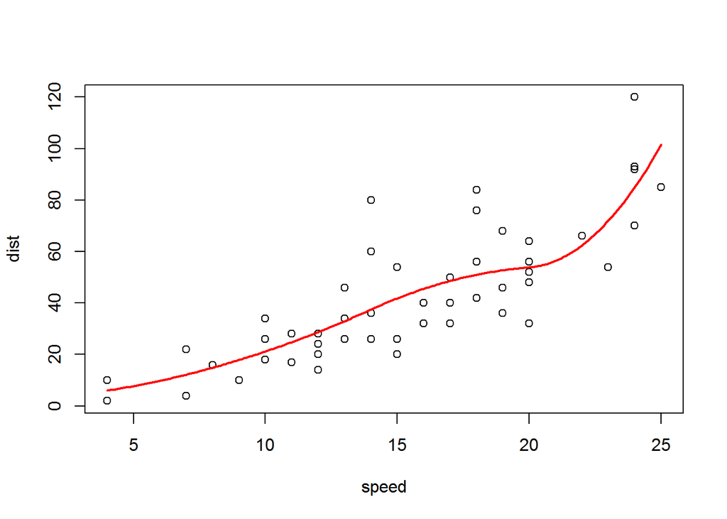

```r
library(splines)
K = c(14, 20)
plot(cars)
reg = lm(dist ~ bs(speed, knots = c(K), degree = 2), data = cars)
u = seq(4, 25, by = 0.1)
B = data.frame(speed = u)
Y = predict(reg, newdata = B)
lines(u, Y, lwd = 2, col = "red")
```

But if we look at the output of the regression, we get this

```r
summary(reg)
```

```
##
## Call:
## lm(formula = dist ~ bs(speed, knots = c(K), degree = 2), data = cars)
##
## Residuals:
##     Min      1Q  Median      3Q     Max
## -21.848  -8.702  -1.667   6.508  42.514
##
## Coefficients:
##                                      Estimate Std. Error t value Pr(>|t|)
## (Intercept)                             5.991      9.692   0.618 0.539596
## bs(speed, knots = c(K), degree = 2)1    8.087     15.278   0.529 0.599174
## bs(speed, knots = c(K), degree = 2)2   45.540     10.735   4.242 0.000109
## bs(speed, knots = c(K), degree = 2)3   49.789     15.704   3.170 0.002738
## bs(speed, knots = c(K), degree = 2)4   95.550     13.651   7.000 1.02e-08
##
## (Intercept)
## bs(speed, knots = c(K), degree = 2)1
## bs(speed, knots = c(K), degree = 2)2 ***
## bs(speed, knots = c(K), degree = 2)3 **
## bs(speed, knots = c(K), degree = 2)4 ***
## ---
## Signif. codes:  0 '***' 0.001 '**' 0.01 '*' 0.05 '.' 0.1 ' ' 1
##
## Residual standard error: 15 on 45 degrees of freedom
## Multiple R-squared:  0.6888, Adjusted R-squared:  0.6611
## F-statistic: 24.89 on 4 and 45 DF,  p-value: 6.491e-11
```

So, what can we do with those numbers ? First, assume know that we consider only one knot (we have to start somewhere), and we consider a b-spline interpolation of degree 1 (i.e. linear by parts).

```r
K = c(14)
reg = lm(dist ~ bs(speed, knots = c(K), degree = 1), data = cars)
summary(reg)
```

```
##
## Call:
## lm(formula = dist ~ bs(speed, knots = c(K), degree = 1), data = cars)
##
## Residuals:
##     Min      1Q  Median      3Q     Max
## -29.523  -9.275  -2.490   5.987  45.227
##
## Coefficients:
##                                      Estimate Std. Error t value Pr(>|t|)
## (Intercept)                             3.290      7.746   0.425   0.6730
## bs(speed, knots = c(K), degree = 1)1   31.483      9.670   3.256   0.0021
## bs(speed, knots = c(K), degree = 1)2   80.525      9.038   8.910 1.16e-11
##
## (Intercept)
## bs(speed, knots = c(K), degree = 1)1 **
## bs(speed, knots = c(K), degree = 1)2 ***
## ---
## Signif. codes:  0 '***' 0.001 '**' 0.01 '*' 0.05 '.' 0.1 ' ' 1
##
## Residual standard error: 15.41 on 47 degrees of freedom
## Multiple R-squared:  0.657,  Adjusted R-squared:  0.6424
## F-statistic: 45.01 on 2 and 47 DF,  p-value: 1.203e-11
```

```r
B = function(x, j, n, K) {
  b = 0
  a1 = a2 = 0
  if (((K[j + n + 1] > K[j + 1]) & (j + n <= length(K)) & (n >
    0)) == TRUE) {
    a2 = (K[j + n + 1] - x)/(K[j + n + 1] - K[j + 1]) * B(x,
      j + 1, n - 1, K)
  }
  if (((K[j + n] > K[j]) & (n > 0)) == TRUE) {
    a1 = (x - K[j])/(K[j + n] - K[j]) * B(x, j, n - 1, K)
  }
  if (n == 0) {
    b = ((x > K[j]) & (x <= K[j + 1])) * 1
  }
  if (n > 0) {
    b = a1 + a2
  }
  return(b)
}
```

So, for instance, for splines of degree 1, we have

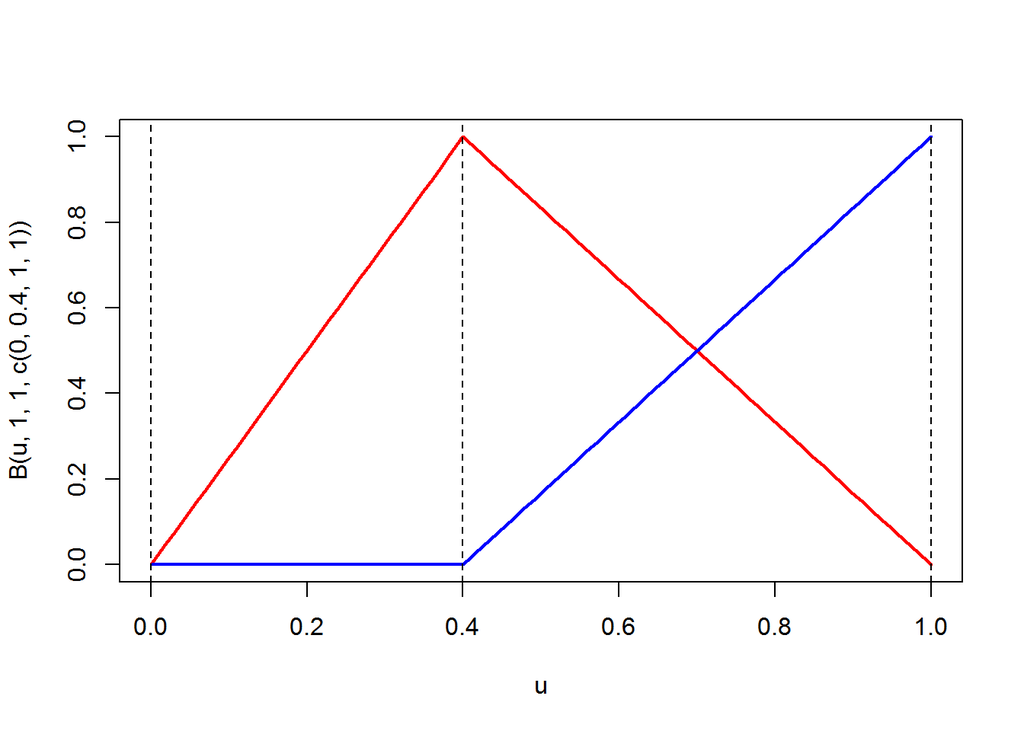

```r
u=seq(0,1,by=.01)
plot(u,B(u,1,1,c(0,.4,1,1)),lwd=2,col="red",type="l",ylim=c(0,1))
lines(u,B(u,2,1,c(0,.4,1,1)),lwd=2,col="blue")
abline(v=c(0,.4,1),lty=2)
```

and for splines of degree 2, the basis is

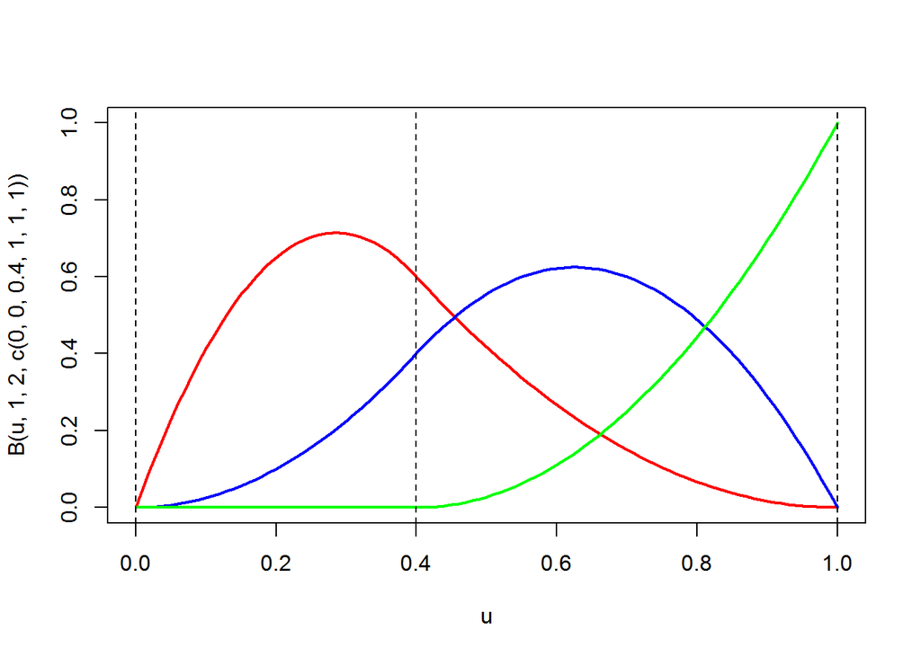

```r
u=seq(0,1,by=.01)
plot(u,B(u,1,2,c(0,0,.4,1,1,1)),lwd=2,col="red",type="l",ylim=c(0,1))
lines(u,B(u,2,2,c(0,0,.4,1,1,1)),lwd=2,col="blue")
lines(u,B(u,3,2,c(0,0,.4,1,1,1)),lwd=2,col="green")
abline(v=c(0,.4,1),lty=2)
```

…etc. Note that I need to duplicate sometimes starting and end points (but it should be possible to fix it in the function). So, how do we use that, here ? Actually, there are two steps:

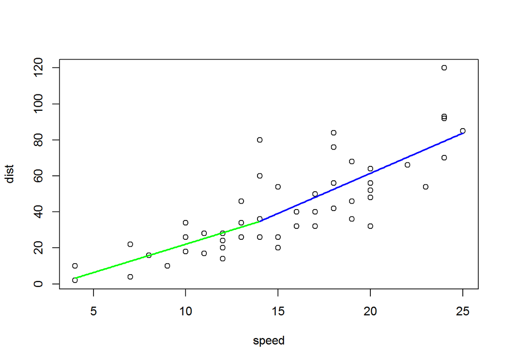

```r
u0=seq(0,1,by=.01)
v=reg$coefficients[2]*u0+reg$coefficients[1]
x1=seq(min(cars$speed),K,length=length(u0))
plot(cars)
lines(x1,v,col="green",lwd=2)
u0=seq(0,1,by=.01)
v=(reg$coefficients[3]-reg$coefficients[2])*u0+ reg$coefficients[1]+reg$coefficients[2]
x2=seq(K,max(cars$speed),length=length(u0))
# plot(u,B(u,1,2,c(0,0,.4,1,1,1)),lwd=2,col="red",type="l",ylim=c(0,1))
lines(x2,v,col="blue",lwd=2)
```

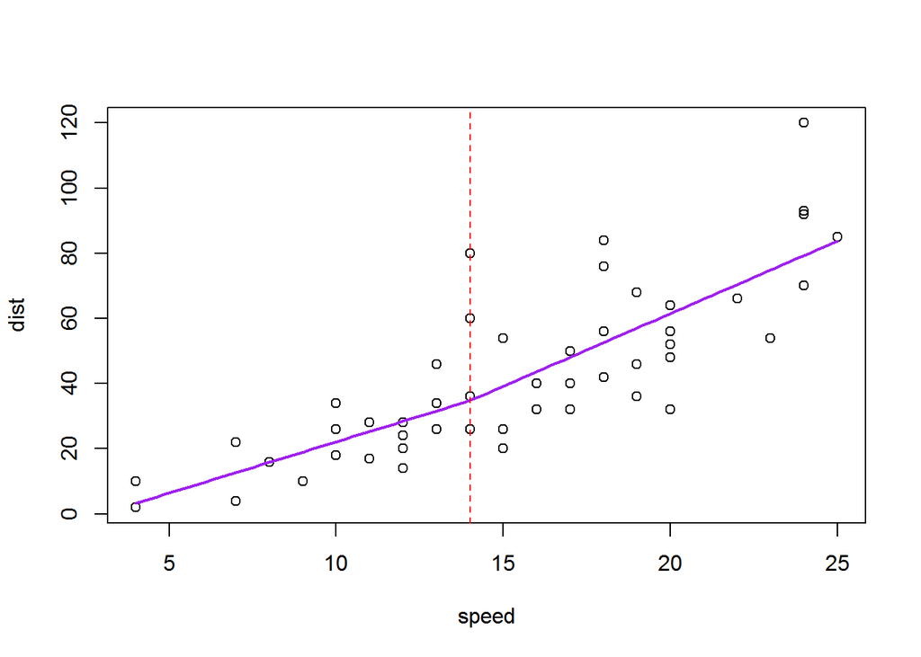

```r
plot(cars)
reg=lm(dist~bs(speed,knots=c(K),degree=1),data=cars)
k=(K-min(cars$speed))/(max(cars$speed)-min(cars$speed))
u0=seq(0,1,by=.01)
v=reg$coefficients[1]+
  reg$coefficients[2]*B(u0,1,1,c(0,k,1,1))+
  reg$coefficients[3]*B(u0,2,1,c(0,k,1,1))
lines(min(cars$speed)+u0*(max(cars$speed)-min(cars$speed)),
v,col="purple",lwd=2)
abline(v=K,lty=2,col="red")
```

So, we should be able to try with two knots (but we keep it linear, so far). Hence

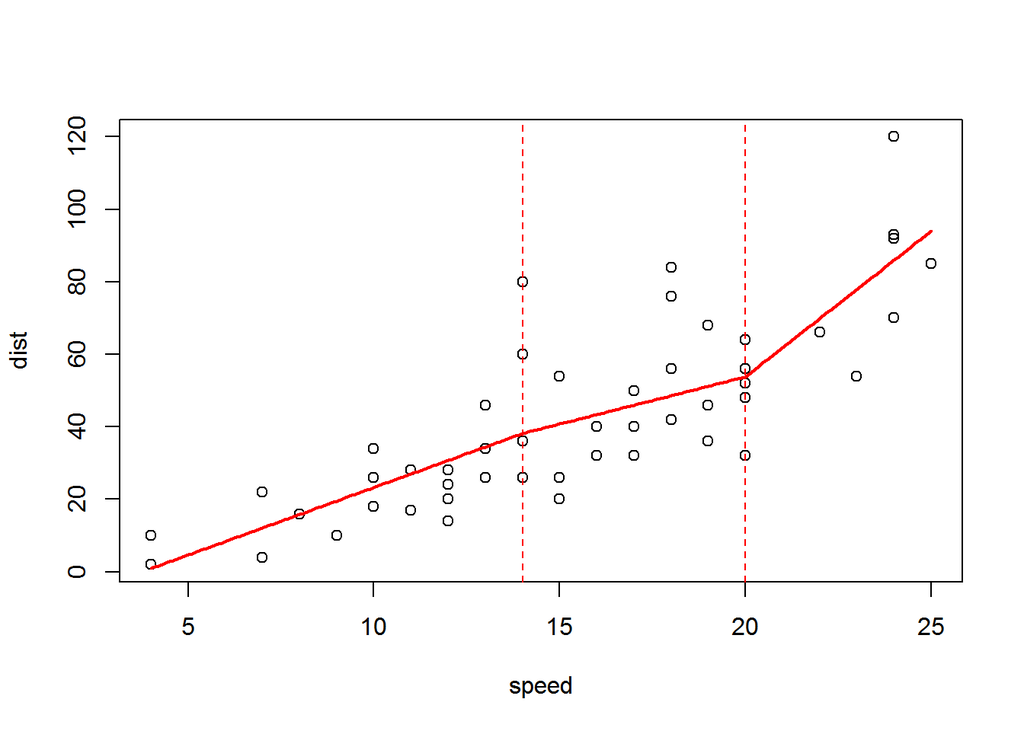

```r
K=c(14,20)
plot(cars)
reg=lm(dist~bs(speed,knots=c(K),degree=1),data=cars)
u=seq(4,25,by=.1)
B_new=data.frame(speed=u)
Y=predict(reg,newdata=B_new)
lines(u,Y,lwd=2,col="red")
abline(v=K,lty=2,col="red")
```

First, we can plot our basis functions, with two knots,

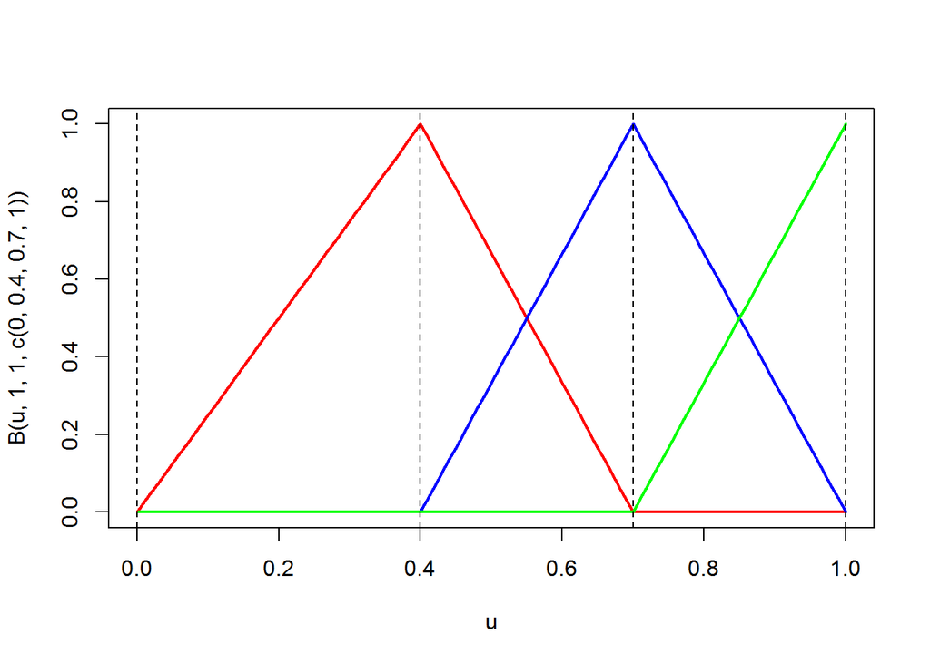

```r
u=seq(0,1,by=.01)
plot(u,B(u,1,1,c(0,.4,.7,1)),lwd=2,col="red",type="l",ylim=c(0,1))
lines(u,B(u,2,1,c(0,.4,.7,1,1)),lwd=2,col="blue")
lines(u,B(u,3,1,c(0,.4,.7,1,1)),lwd=2,col="green")
abline(v=c(0,.4,.7,1),lty=2)
```

so we can use those functions here, as we did before,

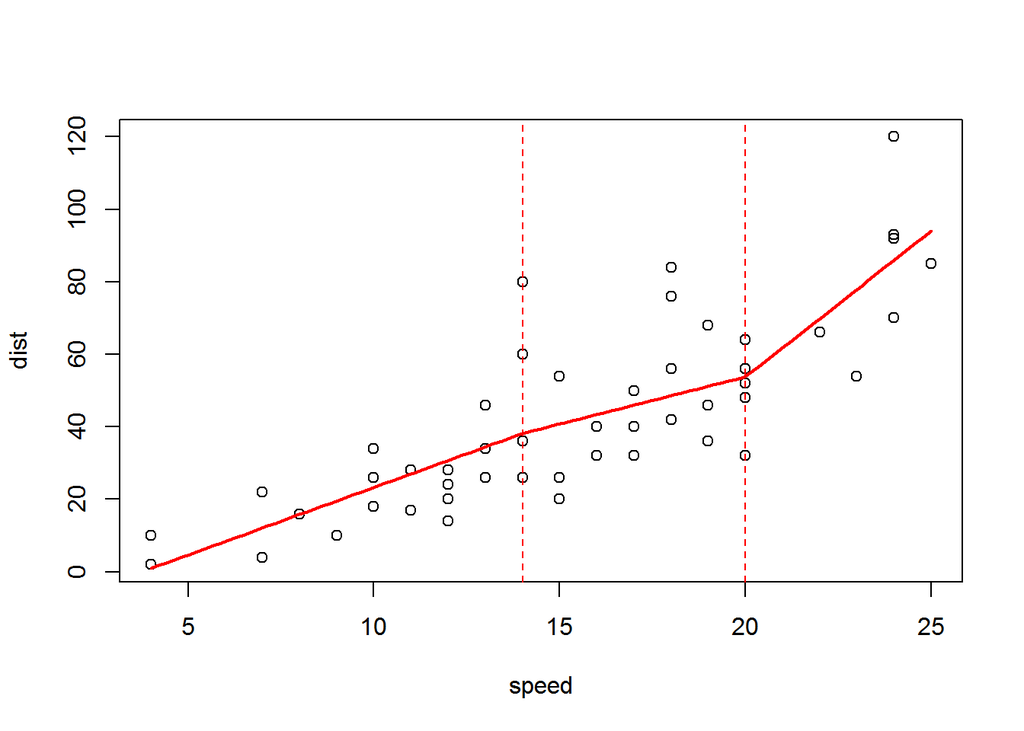

```r
plot(cars)
reg=lm(dist~bs(speed,knots=c(K),degree=1),data=cars)
k=(K-min(cars$speed))/(max(cars$speed)-min(cars$speed))
u0=seq(0,1,by=.01)
v=reg$coefficients[1]+
  reg$coefficients[2]*B(u0,1,1,c(0,k,1,1))+
  reg$coefficients[3]*B(u0,2,1,c(0,k,1,1))+
  reg$coefficients[4]*B(u0,3,1,c(0,k,1,1))
lines(min(cars$speed)+u0*(max(cars$speed)-min(cars$speed)),
v,col="red",lwd=2)
abline(v=K,lty=2,col="red")
```

Great, it looks promising…. Let us look finally at the case we have two knots, and some quadratic splines. Here, with two knots, the basis is

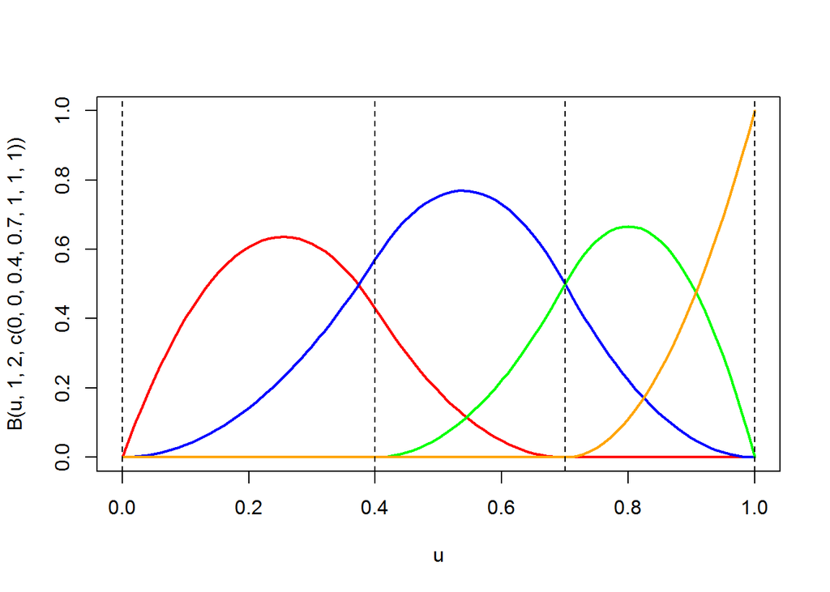

```r
u=seq(0,1,by=.01)
plot(u,B(u,1,2,c(0,0,.4,.7,1,1,1)),lwd=2,col="red",type="l",ylim=c(0,1))
lines(u,B(u,2,2,c(0,0,.4,.7,1,1,1)),lwd=2,col="blue")
lines(u,B(u,3,2,c(0,0,.4,.7,1,1,1)),lwd=2,col="green")
lines(u,B(u,4,2,c(0,0,.4,.7,1,1,1)),lwd=2,col="orange")
abline(v=c(0,.4,.7,1),lty=2)
```

so if we just rewrite our previous function, we have

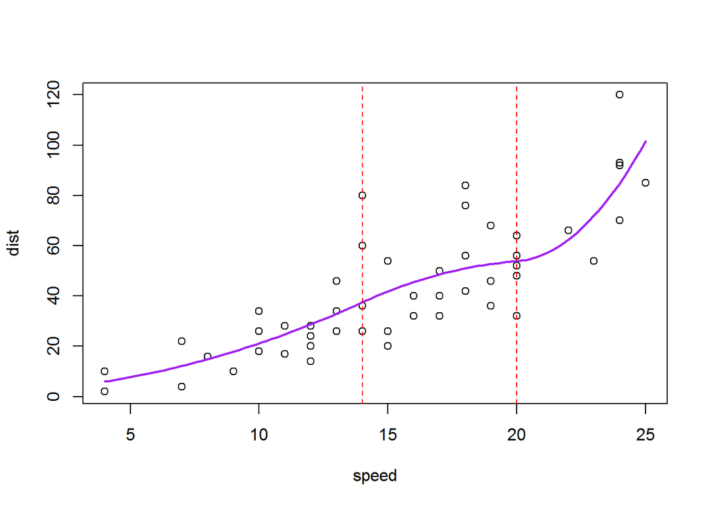

```r
plot(cars)
reg=lm(dist~bs(speed,knots=c(K),degree=2),data=cars)
k=(K-min(cars$speed))/(max(cars$speed)-min(cars$speed))
u0=seq(0,1,by=.01)
v=reg$coefficients[1]+
  reg$coefficients[2]*B(u0,1,2,c(0,0,k,1,1,1))+
  reg$coefficients[3]*B(u0,2,2,c(0,0,k,1,1,1))+
  reg$coefficients[4]*B(u0,3,2,c(0,0,k,1,1,1))+
  reg$coefficients[5]*B(u0,4,2,c(0,0,k,1,1,1))
lines(min(cars$speed)+u0*(max(cars$speed)-min(cars$speed)),
v,col="purple",lwd=2)
abline(v=K,lty=2,col="red")
```

And just one final comment: how do I optimally choose my knots ?… A simple idea can be to consider all possible knots, and consider the model which gives us the residuals with the smaller variance,

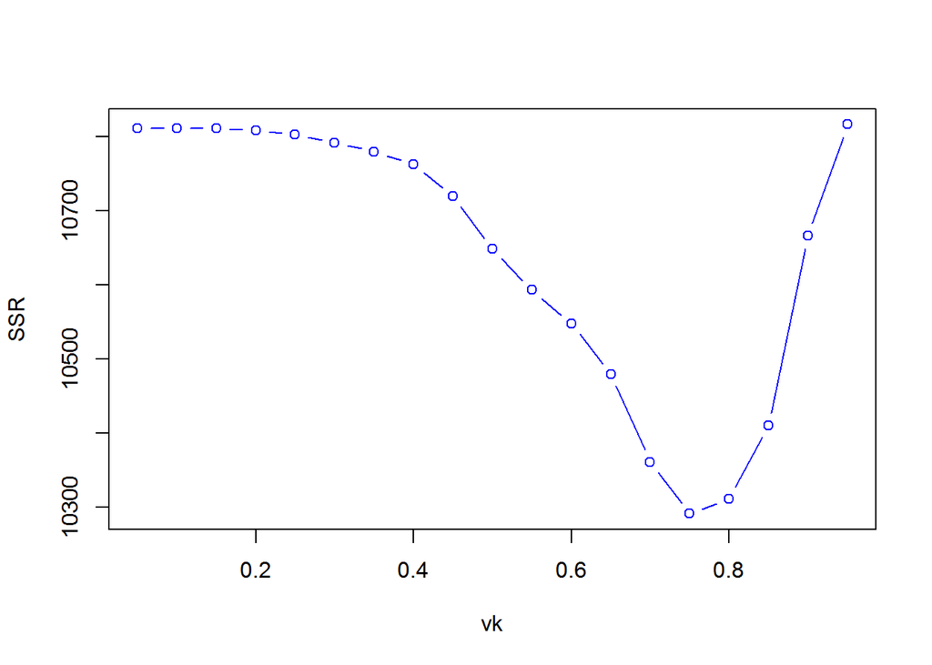

```r
vk=seq(.05,.95,by=.05)
SSR=matrix(NA,length(vk))
for(i in 1:(length(vk))){
k=vk[i]
K=min(cars$speed)+k*(max(cars$speed)-min(cars$speed))
reg=lm(dist~bs(speed,knots=c(K),degree=2),data=cars)
SSR[i]=sum(residuals(reg)^2)
}
plot(vk,SSR,type="b",col="blue")
```

Here, the best model is obtained when we split 3/4-1/4…

- and I know what I am talking about: I have been living in China for more than a year….

展开全文 >>

# English note 27 Oct

2017-10-27

- on the whole
- appear to be a good compromise
- a large proportion of
- the majority of
- Legendre polynomials
- flexible
- modelling 可以翻译成`拟合`
- put a high emphasis on
- notoriously
- oscillation; wiggly
- resulting in
- erratic and implausible 不稳定的和不可信的
- prevalent 普遍的
- pertinent相关的
- efficacy
- be referred to as
- in terms of
- the residual error pertaining to *y_i*
- alleviate
- impose强加
- in essence
- accommodate容纳

展开全文 >>

# implications

2017-10-24

implications